# Tarea 3

Emmanuel Rueda Escalona

## Problema 1: Globalización y liberalización

### 1. Construye un modelo de dinámica de sistemas basado en el caso anterior, simula el modelo por un período de 50 años. Asegúrate que el modelo esté en equilibrio.

```r
library("deSolve")
parameters<-c(depreciation.rate.cI=0.05,
              investment.rate.cI=0.1,
              production.rate.cI=1.0,
              market.volume.cI=1.0,
              market.volume.cII=1.0,
              tax.rate.cI=0.2,
              resource.costs.cI= 1.0,
              standard.factor.cI= 1.0,
              deterioration.rate.cI=0.05,
              reference.price.cI=5.0,

              depreciation.rate.cII=0.05,
              investment.rate.cII=0.1,
              production.rate.cII=1.0,
              market.volume.cII=1.0,
              market.volume.cIII=1.0,
              tax.rate.cII=0.2,
              resource.costs.cII= 1.0,
              standard.factor.cII= 1.0,
              deterioration.rate.cII=0.05,
              reference.price.cII=5.0
              )

Initial.Conditions <- c(production.capacity.cI = 1.0,
                        standards.of.cI=1.0,
                        production.capacity.cII = 0.1,
                        standards.of.cII=0.1
                        )

globalization.and.liberalization<- function(t, state, parameters) {
  with(as.list(c(state,parameters)), {

#País 1
#Variables endógenas
production.costs.cI<-standards.of.cI*standard.factor.cI
product.costs.cI<-resource.costs.cI+production.costs.cI
production.costs.cII<-standards.of.cII*standard.factor.cII
product.costs.cII<-resource.costs.cII+production.costs.cII
product.price.cI<-product.costs.cI*(1+tax.rate.cI)
product.price.cII<-product.costs.cII*(1+tax.rate.cII)
customs.duties.raised.by.cI<-ifelse(t<10,0.5,0)
subsidy.cII<-ifelse(t<10,0,0)
customs.duties.raised.by.cII<-ifelse(t<10,0,0)
subsidy.cI<-ifelse(t<10,0.75,0)
price.of.cII.products.in.cI<-product.price.cII*(1-subsidy.cII+customs.duties.raised.by.cI)
price.of.cI.products.in.cII<-product.price.cI*(1-subsidy.cI+customs.duties.raised.by.cII)
supply.cI<-production.capacity.cI*1*production.rate.cI
price.ratio.of.domestic.versus.imported.products.in.cI<-product.price.cI/price.of.cII.products.in.cI
price.ratio.of.domestic.versus.imported.products.in.cII<-product.price.cII/price.of.cI.products.in.cII
percentage.purchased.by.cI.from.cI<-approx(c(0.0,0.5,1.0,1.5,2.0,5.0),
                                            c(1.0,1.0,0.5,0.0,0.0,0.0),
                                            xout=price.ratio.of.domestic.versus.imported.products.in.cI)$y
percentage.purchased.by.cII.from.cII<- approx(c(0.0,0.5,1.0,1.5,2.0,5.0),
                                            c(1.0,1.0,0.5,0.0,0.0,0.0),
                                            xout=price.ratio.of.domestic.versus.imported.products.in.cII)$y
demand.for.products.from.cI<-percentage.purchased.by.cI.from.cI*market.volume.cI+market.volume.cII*(1-percentage.purchased.by.cII.from.cII)
surplus.cI<-supply.cI-demand.for.products.from.cI
investment.factor.cI<-2
investment.function.cI<-ifelse(t<10,2,investment.factor.cI)
investments.cI<-ifelse(surplus.cI<=0, investment.rate.cI*production.capacity.cI*investment.function.cI, 0)
progress.factor.cI<-2
progress.function.cI<-ifelse(t<10,2,progress.factor.cI)
investments.in.progress.cI<-investments.cI*progress.function.cI
progress.cI<-standards.of.cI*investments.in.progress.cI*(1-product.price.cI/reference.price.cI)

#Variables de flujo
depreciation.cI<-depreciation.rate.cI*production.capacity.cI
deterioration.cI<-standards.of.cI*deterioration.rate.cI

#Variables de estado
dproduction.capacity.cI<-investments.cI-depreciation.cI #porcentaje
dstandards.of.cI<-progress.cI-deterioration.cI

#País 2
#Variables endógenas

supply.cII<-production.capacity.cII*1*production.rate.cII
product.price.cII<-product.costs.cII*(1+tax.rate.cII)
demand.for.products.from.cII<-percentage.purchased.by.cII.from.cII*market.volume.cII+market.volume.cI*(1-percentage.purchased.by.cI.from.cI)
surplus.cII<-supply.cII-demand.for.products.from.cII
investment.factor.cII<-2
investment.function.cII<-ifelse(t<10,0.2,2)
investments.cII<-ifelse(surplus.cII<=0, investment.rate.cII*production.capacity.cII*investment.function.cII, 0)
progress.factor.cII<-2
progress.function.cII<-ifelse(t<10,1,2)
investments.in.progress.cII<-investments.cII*progress.function.cII
progress.cII<-standards.of.cII*investments.in.progress.cII*(1-product.price.cII/reference.price.cII)

#Variables de flujo
depreciation.cII<-depreciation.rate.cII*production.capacity.cII
deterioration.cII<-standards.of.cII*deterioration.rate.cII

#Variables de estado
dproduction.capacity.cII<-investments.cII-depreciation.cII #porcentaje
dstandards.of.cII<-progress.cII-deterioration.cII

list(c(dproduction.capacity.cI,dstandards.of.cI,dproduction.capacity.cII,dstandards.of.cII), investments.cI=investments.cI, investments.cII=investments.cII)
})
}

times<-seq(0, #tiempo inicial
          50, #tiempo final
          1)#número de repeticiones

intg.method<-c("rk4")

out <- ode(y = Initial.Conditions,
           times = times,
           func = globalization.and.liberalization,
           parms = parameters,
           method =intg.method)
```

### 2. Gráfica los efectos sobre production capacity y standards para los dos países.

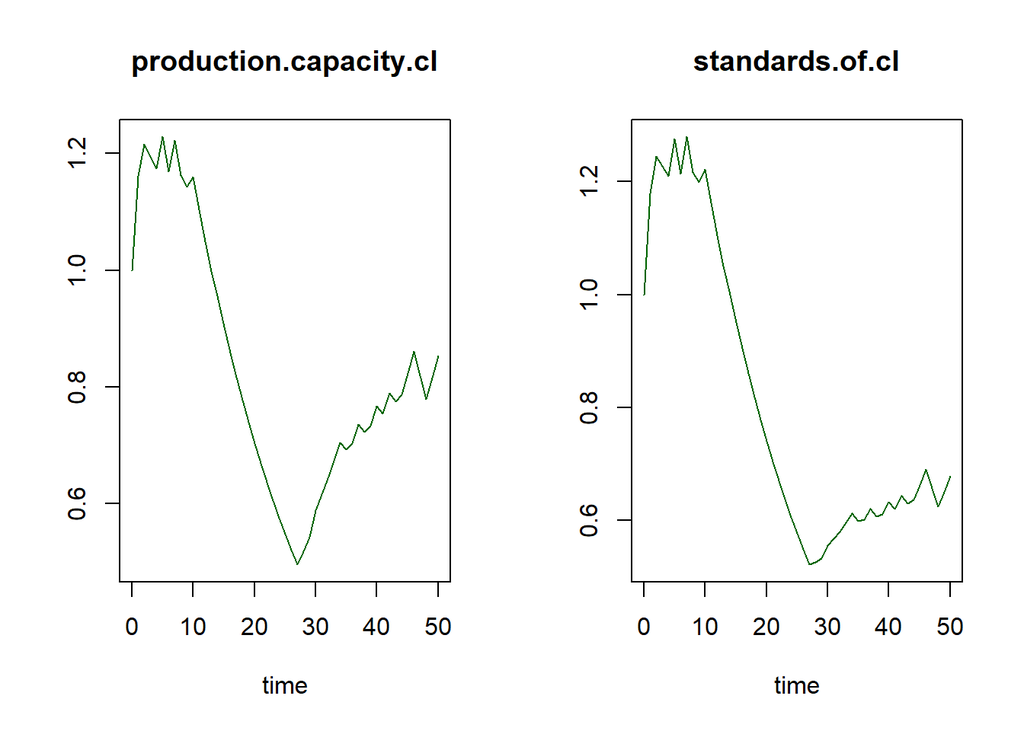

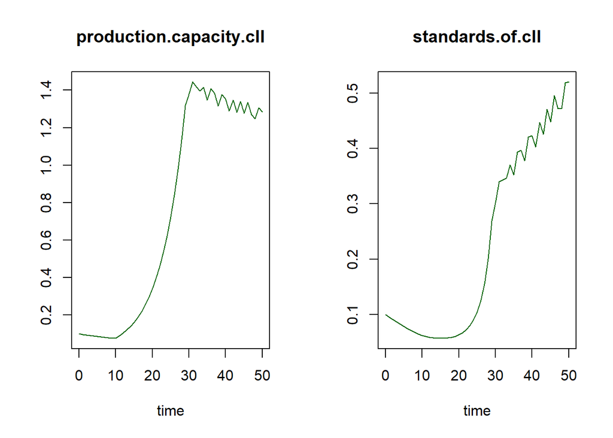

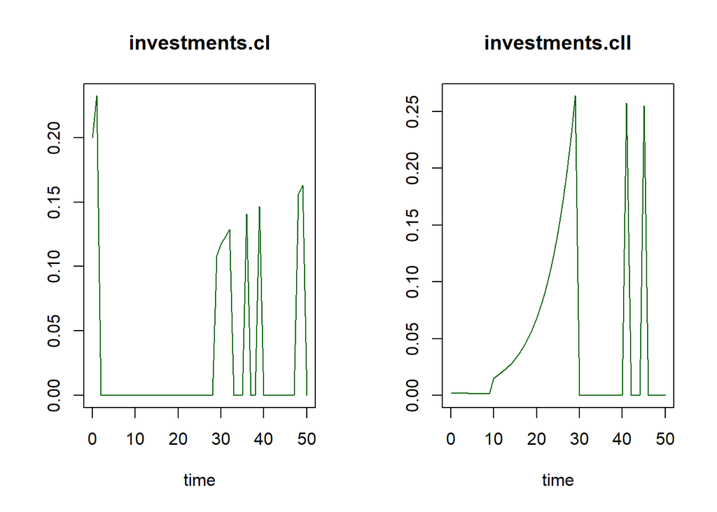

```r
plot(out, mfrow = c(1, 2), col = c("darkgreen"))
```

### 3. Asume que el t=10 el comercio se liberaliza. ¿Qué sucede en los dos países? Explica

Tras la liberación del mercado, la capacidad de producción del país 1 se desploma debido al incremento de las inversiones en el país 2.

Antes de la liberación la capacidad de producción y los estandares del país 2 estan muy por debajo del país 1. La globalización fue determinante para que el país 2 alcanzara la estabilidad debido a que la globalización detonó un cambio en las funciones de inversión y progreso, ambas variables de estado.

### 4. Construye un diagrama causal del modelo o un diagrama stock-and-flow simplificado. Emplea este diagrama para describir el comportamiento que observas.

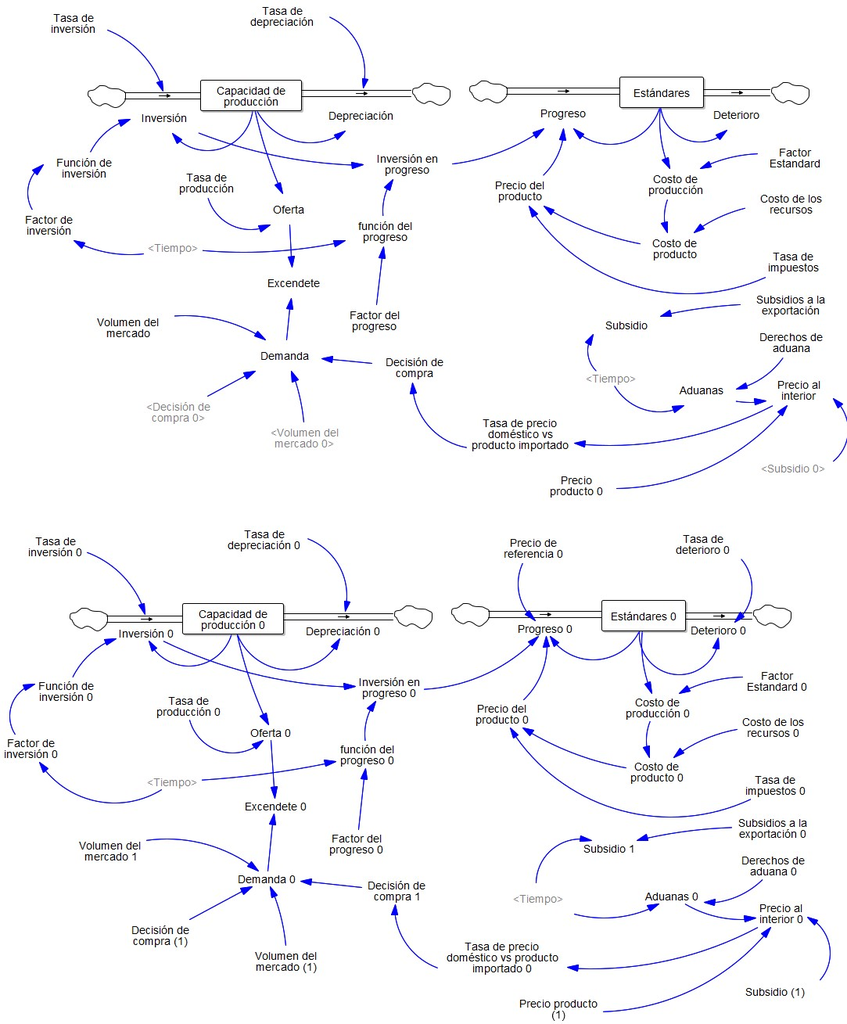

### 5. Construye un diagrama de fase que englobe los principales elementos dinámicos del modelo. ¿Qué trayectoria sigue el sistema si inicia bajo diferentes condiciones iniciales?, ¿cuántos puntos de equilibrio identificas?, ¿son estables o inestables?

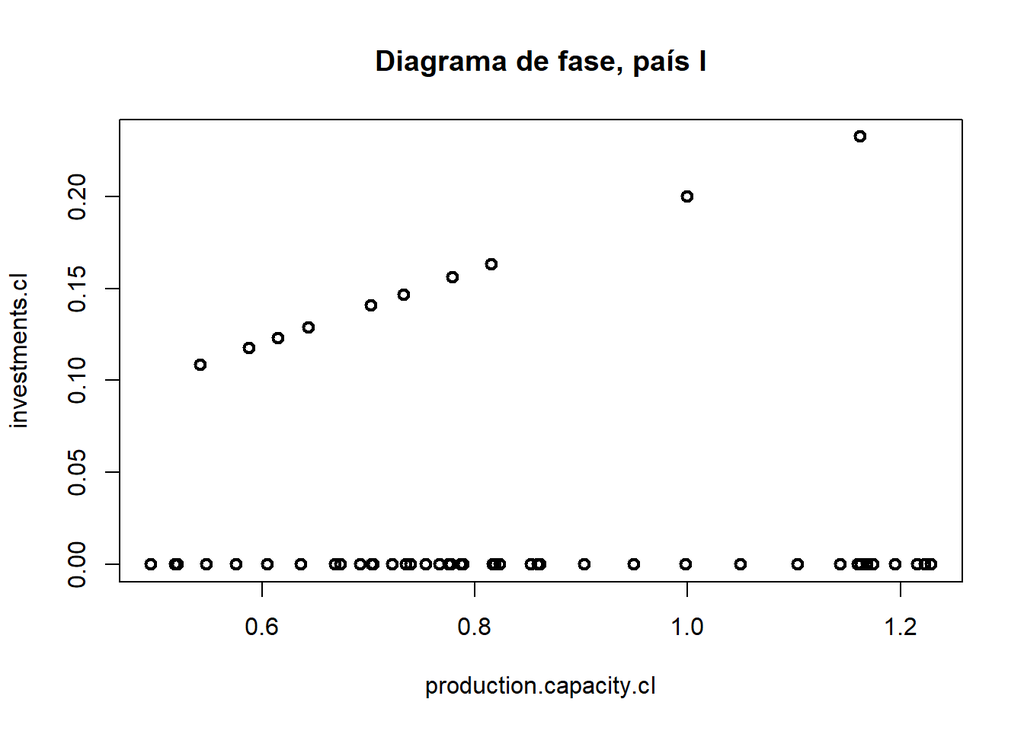

```r
plot(out[,"production.capacity.cI"], out[,"investments.cI"], xlab="production.capacity.cI", ylab = "investments.cI", type = "p", lwd = 2, main="Diagrama de fase, país I")
```

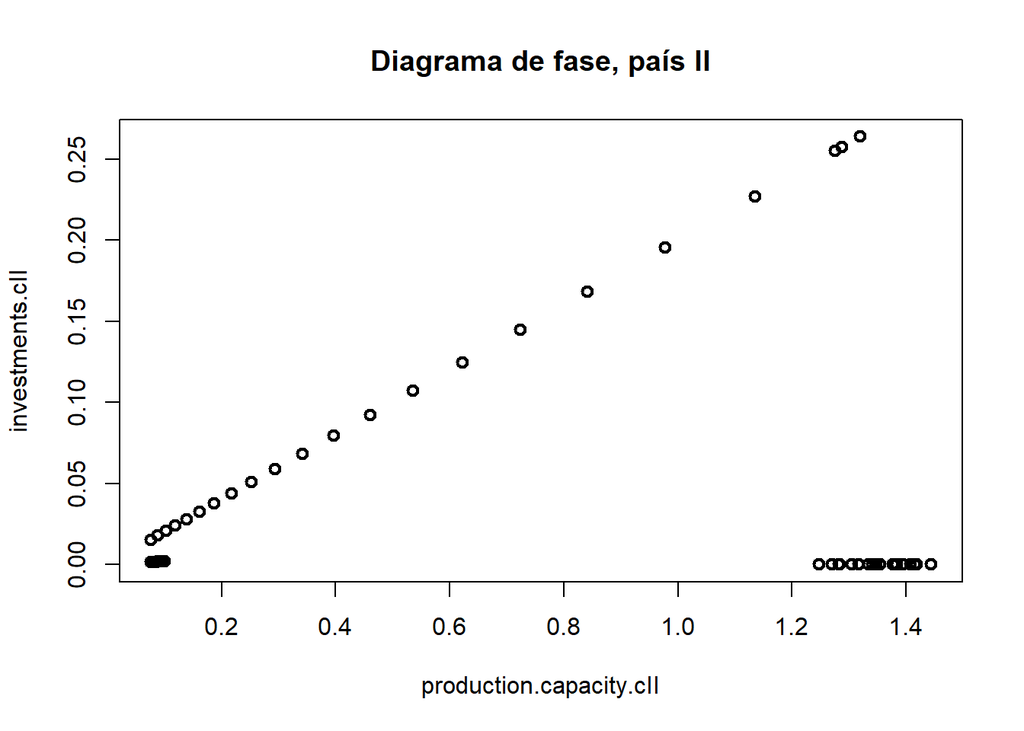

```r
plot(out[,"production.capacity.cII"], out[,"investments.cII"], xlab="production.capacity.cII", ylab = "investments.cII", type = "p", lwd = 2, main="Diagrama de fase, país II")
```

Ambos sistemas tienen una trayectoria lineal. El país 1 tiene varios puntos de equilibrio a los que se llega cuando su capacidad de producción está al 75% y 115%, tendiendo a un comportamiento de inestabilidad. El país 2 se puede identificar que el equilibrio se alcanza hasta que la capacidad de producción llega a 135% aproximadamente, presentando un comportamiento estable.

## Problema 2: Colapso de Civilizaciones

### Construye un modelo de dinámica de sistemas basado en el caso anterior. Calcula el valor de los exponentes y las variables de flujo omitidas de tal manera que el colapso de la población Maya ocurra en el año 800. Simula 2000 años de evolución iniciando en el año 1,000 A.C.

```r
collapse.of.civilizations<- function(t, state, parameters) {
  with(as.list(c(state,parameters)), {

#Variables endógenas
food.produced<-fertility.of.lands*agricultural.land
demand.for.food<-consumed.food.per.person*population
gap<-demand.for.food-food.produced

#Variables de flujo
deforestation<-min(gap/max(fertility.of.lands,1),forest/4)/intensity
fertility.losses<-fertility.of.lands*min(2,(agricultural.land/forest)^1.5)/intensity
natural.population.increase<-population*natural.increase.rate
emigration<-(gap/consumed.food.per.person)*emigration.ratio

#Variables de estado
dagricultural.land<- deforestation
dforest<- -1*deforestation
dfertility.of.lands<- -1*fertility.losses
dpopulation<-natural.population.increase-emigration


list(c(dforest, dagricultural.land, dfertility.of.lands, dpopulation), deforestation=deforestation, fertility.losses=fertility.losses)
  })
}

parameters2<-c(intensity=1,
              emigration.ratio=0.05,
              consumed.food.per.person=200, #kg por persona por año
              natural.increase.rate=(2^(1/408)-1))

InitialConditions2 <- c(forest = 5000,
                      agricultural.land=8,
                      fertility.of.lands=5000000,
                      population=100000)

times2 <- seq(-1000, #tiempo inicial
             1000, #tiempo final
             1) #lapso de tiempo

intg.method<-c("rk4")

#Simulate model

out2 <- ode(y = InitialConditions2,
           times = times2,
           func = collapse.of.civilizations,
           parms = parameters2,
           method =intg.method )
```

### 2. ¿Qué pasa con la población? Gráfica el comportamiento de esta variable, ¿corresponde el comportamiento de tu modelo al comportamiento observado?

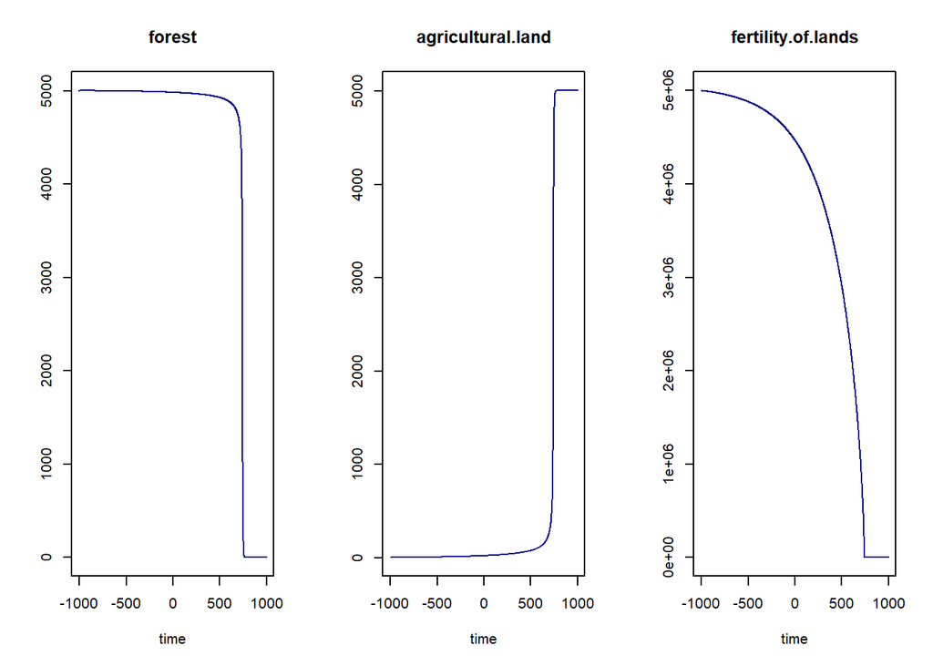

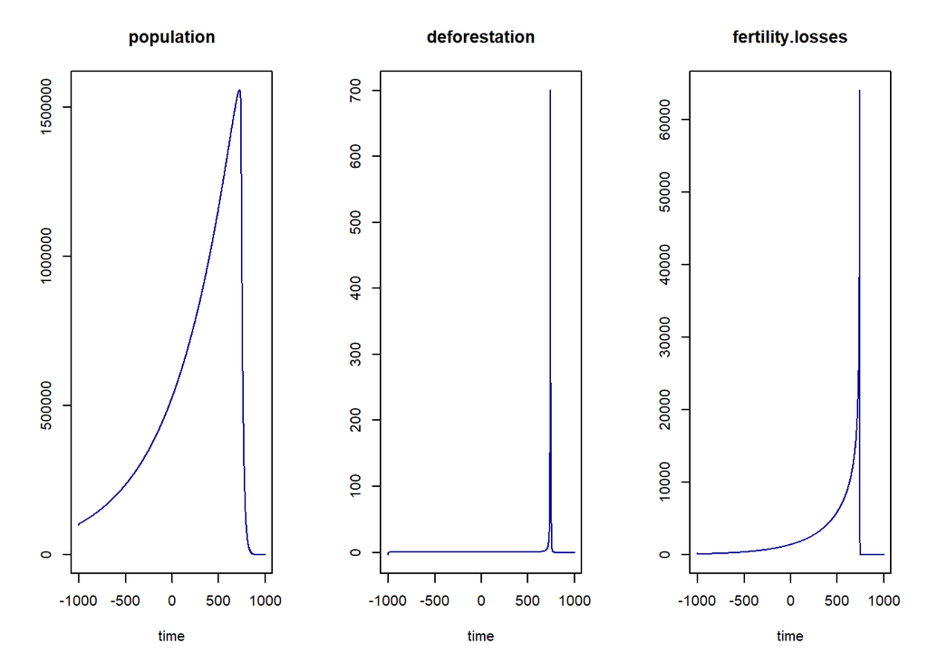

```r
plot(out2, mfrow = c(1, 3), col = c("darkblue"))
```

La población empieza a colapsar hasta su desaparición alrededor del año 800

### 3. Introduce cambios en el modelo que hagan más realista su comportamiento

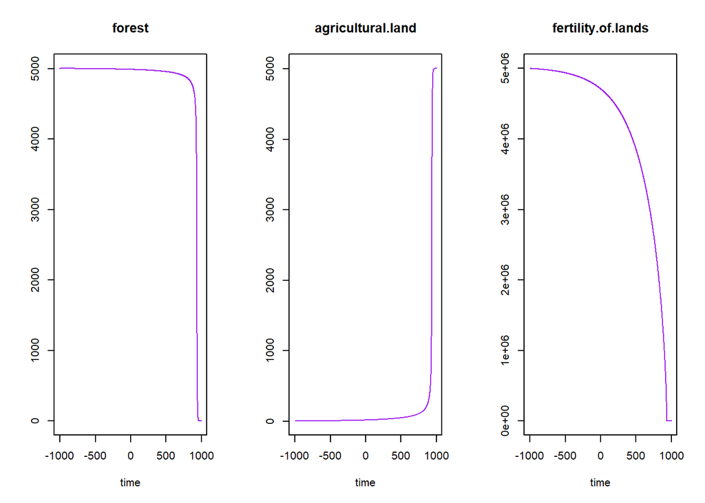

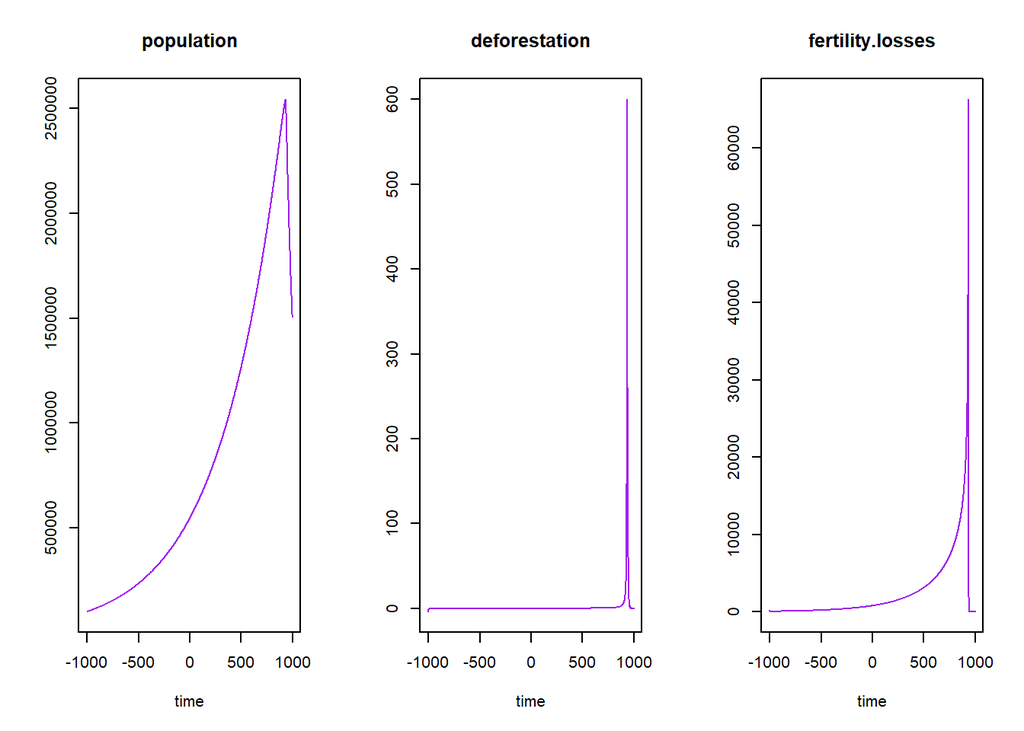

```r
collapse.of.civilizations2<- function(t, state, parameters) {
  with(as.list(c(state,parameters)), {

#Variables endogenas
food.produced<-fertility.of.lands*agricultural.land
demand.for.food<-consumed.food.per.person*population
gap<-demand.for.food-food.produced

#Variables de flujo
deforestation<-min(gap/max(fertility.of.lands,1),forest/4)/intensity
fertility.losses<-fertility.of.lands*min(2,(agricultural.land/forest)^1.5)/intensity
natural.population.increase<-population*natural.increase.rate
emigration<-(gap/consumed.food.per.person)*emigration.ratio

#Variables de stock
dagricultural.land<- deforestation
dforest<- -1*deforestation
dfertility.of.lands<- -1*fertility.losses
dpopulation<-natural.population.increase-emigration


list(c(dforest, dagricultural.land, dfertility.of.lands, dpopulation), deforestation=deforestation, fertility.losses=fertility.losses)
  })
}

parameters3<-c(intensity=1.2,
              emigration.ratio=0.01,
              consumed.food.per.person=150, #kg per person per year
              natural.increase.rate=(2^(1/408)-1))

InitialConditions3 <- c(forest = 5000,
                      agricultural.land=8,
                      fertility.of.lands=5000000,
                      population=100000)

times3 <- seq(-1000, #tiempo inicial
             1000, #tiempo final
             1) #lapso de tiempo

intg.method<-c("rk4")

#Simulate model

out3 <- ode(y = InitialConditions3,
           times = times3,
           func = collapse.of.civilizations2,
           parms = parameters3,
           method =intg.method )

plot(out3, mfrow = c(1, 3), col = c("purple"))
```

**Se puede ver un retraso en el tiempo de colapso si se aumenta la intensidad en 20%, la emigración se reduce al 1% y el consumo de comida por persona cambia a 150 kg anuales.**

### 4. ¿Qué tan sensible es el modelo a cambios marginales en los parámetros o a cambios estructurales? Presenta al menos dos ejemplos.

Ejemplo 1. Con cambios marginales

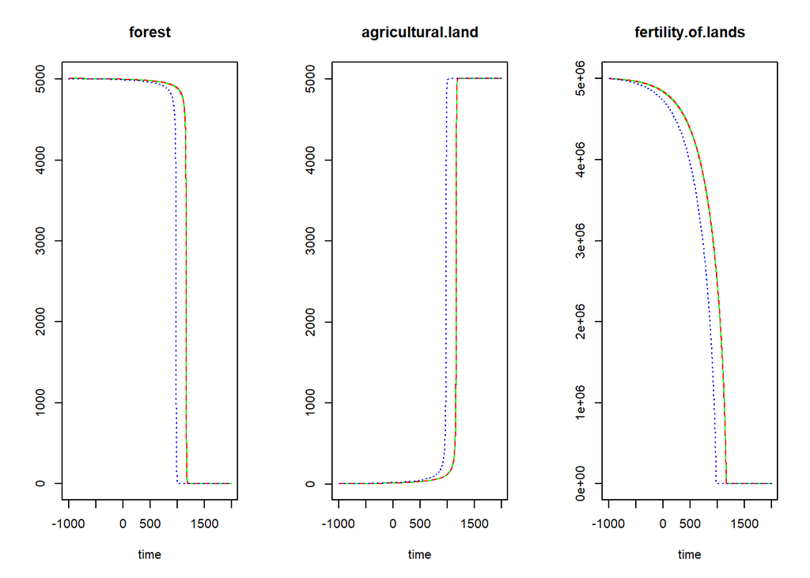

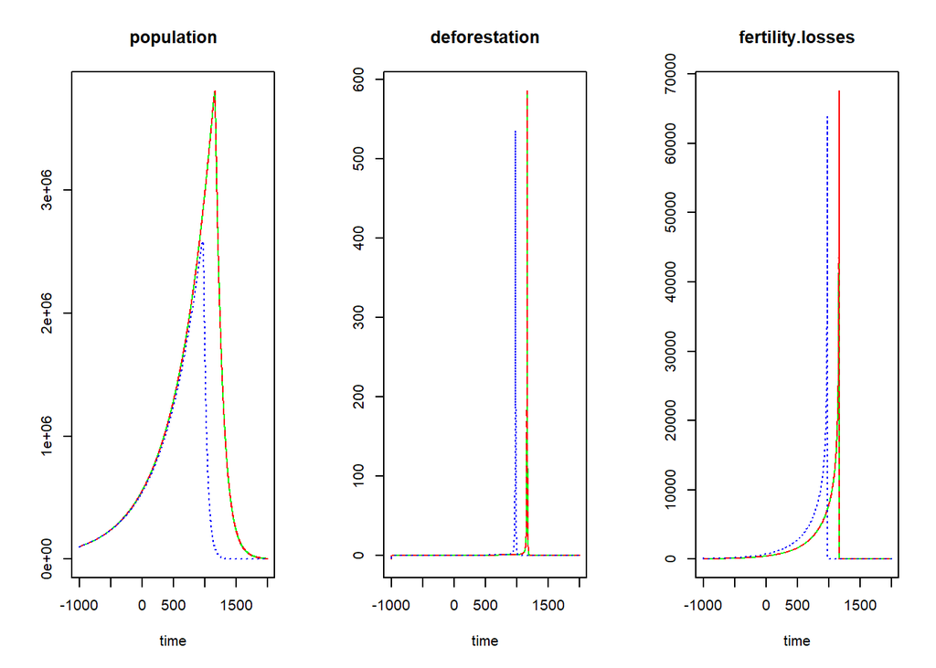

```r
collapse.of.civilizations3<- function(t, state, parameters) {
  with(as.list(c(state,parameters)), {

#Variables endogenas
food.produced<-fertility.of.lands*agricultural.land
demand.for.food<-consumed.food.per.person*population
gap<-demand.for.food-food.produced

#Variables de flujo
deforestation<-min(gap/max(fertility.of.lands,1),forest/4)/intensity
fertility.losses<-fertility.of.lands*min(2,(agricultural.land/forest)^1.5)/intensity
natural.population.increase<-population*natural.increase.rate
emigration<-(gap/consumed.food.per.person)*emigration.ratio

#Variables de estado
dagricultural.land<- deforestation
dforest<- -1*deforestation
dfertility.of.lands<- -1*fertility.losses
dpopulation<-natural.population.increase-emigration


list(c(dforest, dagricultural.land, dfertility.of.lands, dpopulation), deforestation=deforestation, fertility.losses=fertility.losses)
  })
}

parameters4<-c(intensity=1.2,
              emigration.ratio=0.01,
              consumed.food.per.person=100, #kg per person per year
              natural.increase.rate=(2^(1/408)-1))

parameters5<-c(intensity=1.3,
              emigration.ratio=0.02,
              consumed.food.per.person=150, #kg per person per year
              natural.increase.rate=(2^(1/408)-1))

parameters6<-c(intensity=1.4,
              emigration.ratio=0.03,
              consumed.food.per.person=200, #kg per person per year
              natural.increase.rate=(2^(1/408)-1))

InitialConditions4 <- c(forest = 5000,
                      agricultural.land=8,
                      fertility.of.lands=5000000,
                      population=100000)

times4 <- seq(-1000, #tiempo inicial
             2000, #tiempo final
             1) #lapso de tiempo

intg.method<-c("rk4")

#Modelo

out4 <- ode(y = InitialConditions4,
           times = times4,
           func = collapse.of.civilizations3,
           parms = parameters4,
           method =intg.method )

out5 <- ode(y = InitialConditions4,
           times = times4,
           func = collapse.of.civilizations3,
           parms = parameters5,
           method =intg.method )

out6 <- ode(y = InitialConditions4,
           times = times4,
           func = collapse.of.civilizations3,
           parms = parameters6,
           method =intg.method )


plot(out4, out4, out5, mfrow = c(1, 3), col = c("green", "red", "blue"))
```

**Ante cambios marginales el comportamiento es el mismo, sólo se retrasan los efectos.**

Ejemplo 2. Con cambios estructurales

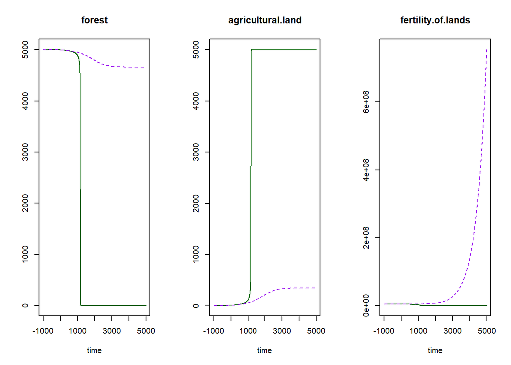

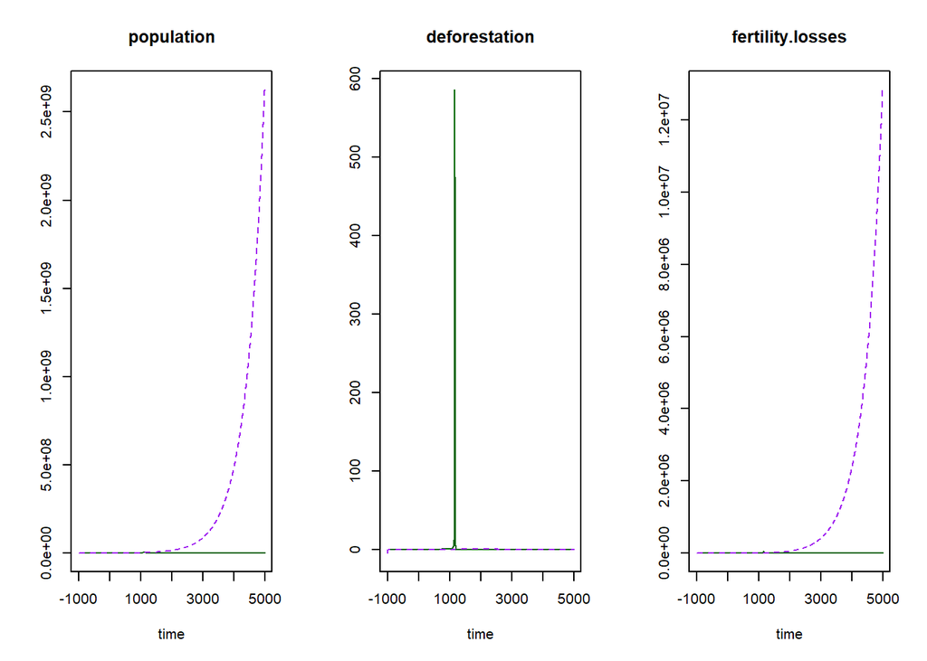

```r
collapse.of.civilizations4<- function(t, state, parameters) {
  with(as.list(c(state,parameters)), {

#Variables Endogenas
food.produced<-fertility.of.lands*agricultural.land
demand.for.food<-consumed.food.per.person*population
gap<-demand.for.food-food.produced

#Variables de flujo
deforestation<-min(gap/max(fertility.of.lands,1),forest/4)/intensity
fertility.losses<-fertility.of.lands*min(2,(agricultural.land/forest)^1.5)/intensity
natural.population.increase<-population*natural.increase.rate
emigration<-(gap/consumed.food.per.person)*emigration.ratio

#Variables de Estao
dagricultural.land<- deforestation
dforest<- -1*deforestation
dfertility.of.lands<- -1*fertility.losses
dpopulation<-natural.population.increase-emigration


list(c(dforest, dagricultural.land, dfertility.of.lands, dpopulation), deforestation=deforestation, fertility.losses=fertility.losses)
  })
}

collapse.of.civilizations5<- function(t, state, parameters) {
  with(as.list(c(state,parameters)), {

#Variables endogenas
food.produced<-fertility.of.lands*agricultural.land
demand.for.food<-consumed.food.per.person*population
gap<-demand.for.food-food.produced

#Variables de flujo
deforestation<-min(gap/max(fertility.of.lands,1),forest/4)/intensity
fertility.losses<-fertility.of.lands*min(2,(agricultural.land/forest)^1.5)/intensity
natural.population.increase<-population*natural.increase.rate
emigration<-(gap/consumed.food.per.person)*emigration.ratio
fertility.recuperation<-0.6*fertility.losses

#Variables de Estado
dagricultural.land<- deforestation
dforest<- -1*deforestation
dfertility.of.lands<- -0.5*fertility.losses+fertility.recuperation
dpopulation<-natural.population.increase-emigration


list(c(dforest, dagricultural.land, dfertility.of.lands, dpopulation), deforestation=deforestation, fertility.losses=fertility.losses)
  })
}

parameters7<-c(intensity=1.2,
              emigration.ratio=0.01,
              consumed.food.per.person=100, #kg per person per year
              natural.increase.rate=(2^(1/408)-1))

InitialConditions5 <- c(forest = 5000,
                      agricultural.land=8,
                      fertility.of.lands=5000000,
                      population=100000)

times5 <- seq(-1000, #initial time
             5000, #end of simulation
             1) #time step

intg.method<-c("rk4")

#Modelo

out7 <- ode(y = InitialConditions5,
           times = times5,
           func = collapse.of.civilizations4,
           parms = parameters7,
           method =intg.method )

out8 <- ode(y = InitialConditions5,
           times = times5,
           func = collapse.of.civilizations5,
           parms = parameters7,
           method =intg.method )

plot(out7, out8, mfrow = c(1, 3), col = c("darkgreen", "purple"))
```

**El modelo es muy sensible ante cambios estructurales. Agregando variables que pudieran contrarestar el efecto negativo de otras, pueden provocar que el modelo no llegue al colapso.**

### 5. Propón una política (i.e. preferentemente una política dinámica) que evite el colapso de la civilización Maya. Implementa esta política en el modelo y compara gráficamente el comportamiento del sistema con y sin tu política.

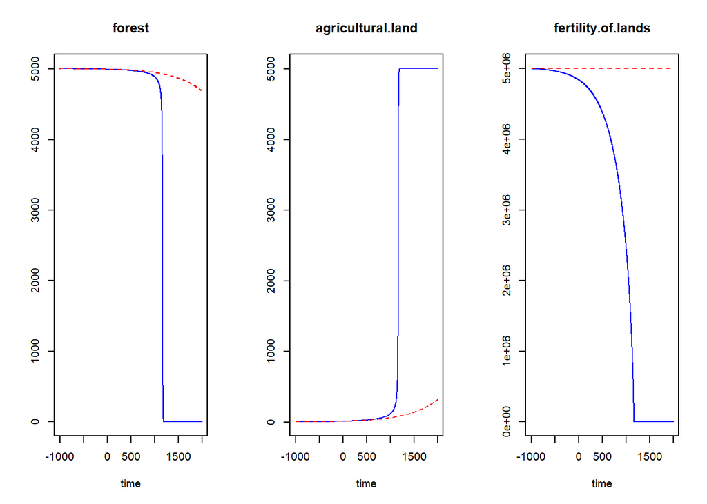

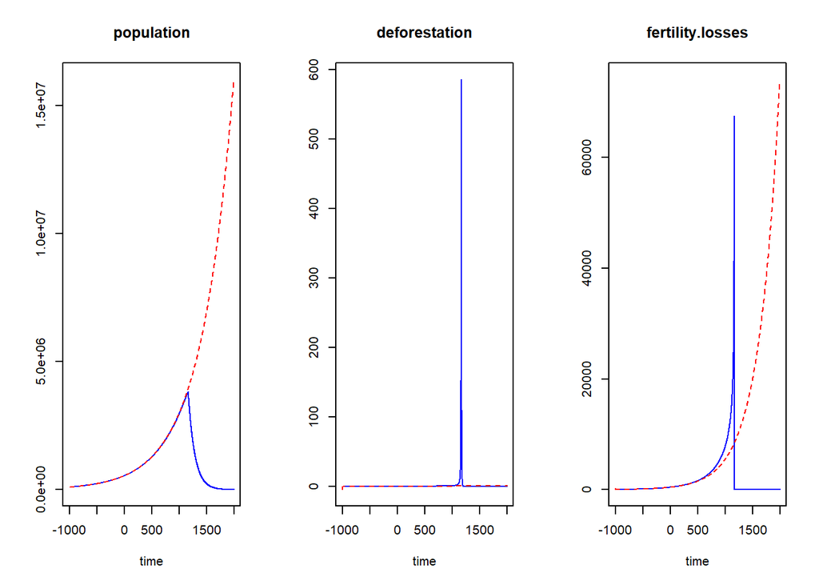

```r
collapse.of.civilizations5<- function(t, state, parameters) {
  with(as.list(c(state,parameters)), {

#Variables endogenas
food.produced<-fertility.of.lands*agricultural.land
demand.for.food<-consumed.food.per.person*population
gap<-demand.for.food-food.produced

#Variables de flujo
deforestation<-min(gap/max(fertility.of.lands,1),forest/4)/intensity
fertility.losses<-fertility.of.lands*min(2,(agricultural.land/forest)^1.5)/intensity
natural.population.increase<-population*natural.increase.rate
emigration<-(gap/consumed.food.per.person)*emigration.ratio

#Variables de Estado
dagricultural.land<- deforestation
dforest<- -1*deforestation
dfertility.of.lands<- -1*fertility.losses
dpopulation<-natural.population.increase-emigration


list(c(dforest, dagricultural.land, dfertility.of.lands, dpopulation), deforestation=deforestation, fertility.losses=fertility.losses)
  })
}

collapse.of.civilizations6<- function(t, state, parameters) {
  with(as.list(c(state,parameters)), {

#Variables Endogenas
food.produced<-fertility.of.lands*agricultural.land
demand.for.food<-consumed.food.per.person*population
gap<-demand.for.food-food.produced

#Variables de flujo
deforestation<-min(gap/max(fertility.of.lands,1),forest/4)/intensity
fertility.losses<-fertility.of.lands*min(2,(agricultural.land/forest)^1.5)/intensity
natural.population.increase<-population*natural.increase.rate
emigration<-(gap/consumed.food.per.person)*emigration.ratio
fertility.recuperation<-0.5*fertility.losses

#Variables de Estado
dagricultural.land<- deforestation
dforest<- -1*deforestation
dfertility.of.lands<- -0.5*fertility.losses+fertility.recuperation
dpopulation<-natural.population.increase-emigration


list(c(dforest, dagricultural.land, dfertility.of.lands, dpopulation), deforestation=deforestation, fertility.losses=fertility.losses)
  })
}

parameters8<-c(intensity=1.2,
              emigration.ratio=0.01,
              consumed.food.per.person=100, #kg per person per year
              natural.increase.rate=(2^(1/408)-1))

InitialConditions8 <- c(forest = 5000,
                      agricultural.land=8,
                      fertility.of.lands=5000000,
                      population=100000)

times8 <- seq(-1000, #tiempo inicial
             2000, #tiempo final
             1) #lapso

intg.method<-c("rk4")



out8 <- ode(y = InitialConditions8,
           times = times8,
           func = collapse.of.civilizations5,
           parms = parameters8,
           method =intg.method )

out9 <- ode(y = InitialConditions8,
           times = times8,
           func = collapse.of.civilizations6,
           parms = parameters8,
           method =intg.method )

plot(out8, out9, mfrow = c(1, 3), col = c("blue", "red"))
```

### 5. Construye un diagrama de fase del modelo sin política. ¿Cuál es tu conclusión?, ¿cómo cambia este diagrama de fase con tu política?

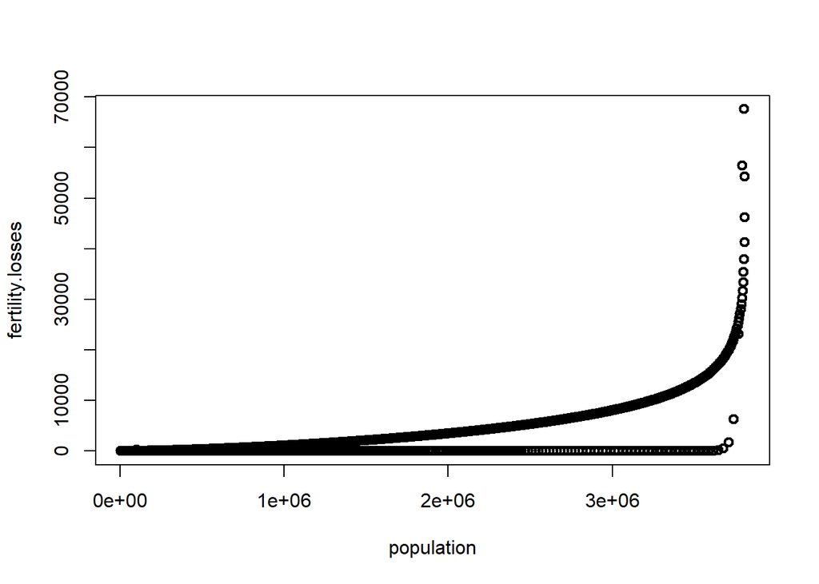

```r
plot(out8[,"population"], out8[,"fertility.losses"], xlab="population", ylab = "fertility.losses", type = "p", lwd = 2)
```

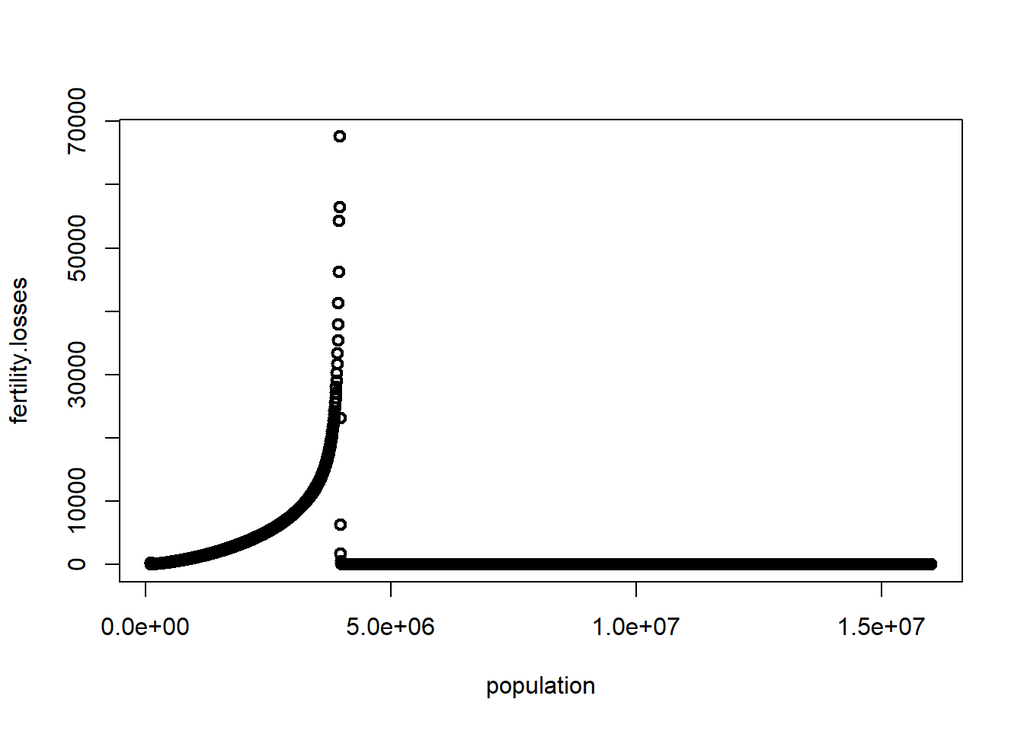

```r
plot(out9[,"population"], out8[,"fertility.losses"], xlab="population", ylab = "fertility.losses", type = "p", lwd = 2)
```